# datafes

Wenxuan Dan

2019/11/16

## R Markdown

We want to find the relationship between education,income,rate of adherent population over county population.

We regress income vs rate

we can find the distribution of rate, income and percentage of people having above highschool diploma is skewed, we think it is better to perform a log transformation Then we are interested in using different model

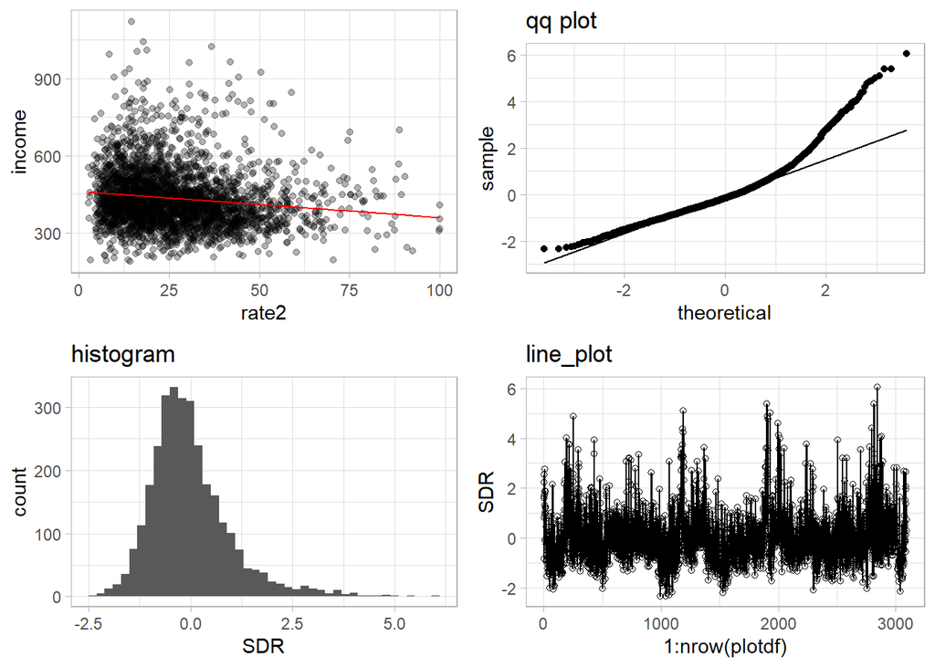

```r
#2010
mod2010<-my_model(test2010_)[[3]]
testplot2010<-mutatedata(test2010_,mod2010)
g<-drawgrid(testplot2010,'rate2','income')
grid.arrange(g[[1]],g[[2]],g[[3]],g[[4]],ncol=2)
```

The distribution is right skewed from the qqplot and histogram,  
the independence is not violated. we now consider using a log transformation on the model

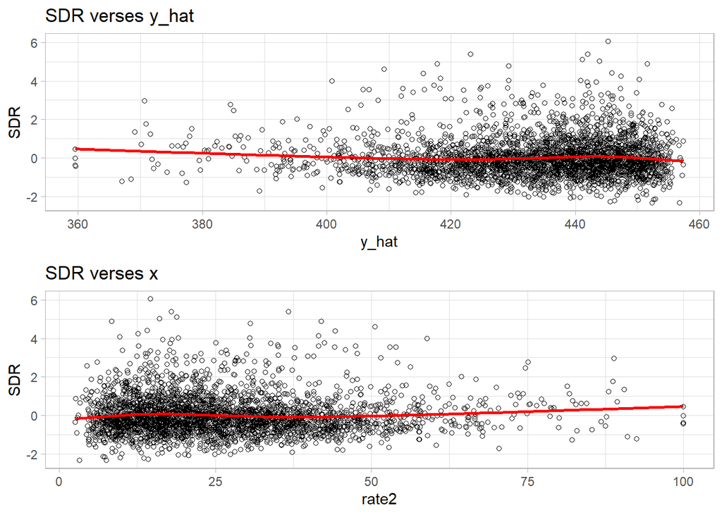

```r
grid.arrange(g[[5]],g[[6]],nrow=2)
```

The residual plots shows linearity. but the residual shows a microphone shape, constant variance is violated

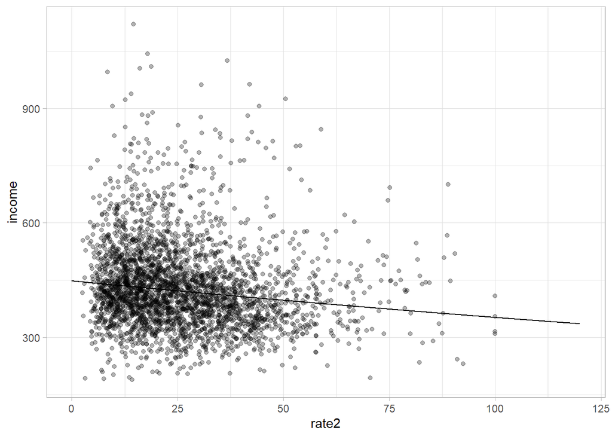

```r
modellog<-lm(log10(income)~rate2,data=test2010_)
testplot1980<-mutatedata(test2010_,modellog)
grid<-tibble(x=seq(0,120,length.out=1000),y=10^(2.651181-0.001044*seq(0,120,length.out=1000) ))
ggplot(testplot1980,aes(x=rate2,y=income))+
  geom_point(alpha=0.3)+
  geom_line(grid,mapping=aes(x=x,y=y))
```

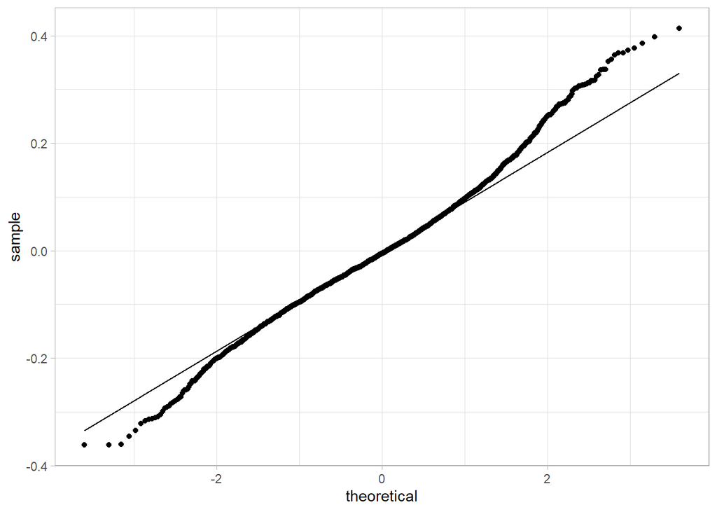

```r
ggplot(testplot1980,aes(sample=resid))+
  stat_qq()+
  stat_qq_line()
```

we observe the similar pattern for the other three year,thus we will do log transformation for the other three years, together with weighted variance.

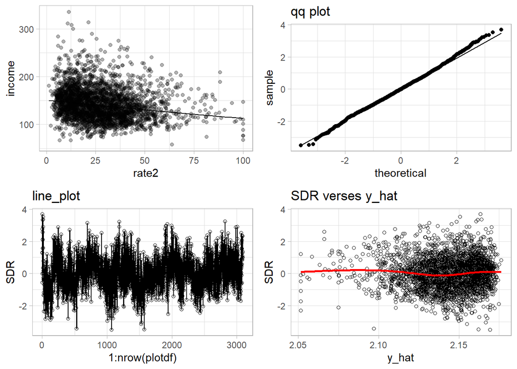

```r
#1980

mod1980<-my_model(test1980_)[[1]]
testplot1980<-mutatedata(test1980_,mod1980)
g80<-drawgrid(testplot1980,'rate2','income')
grid.arrange(g80[[7]],g80[[2]],g80[[4]],g80[[5]],ncol=2)
```

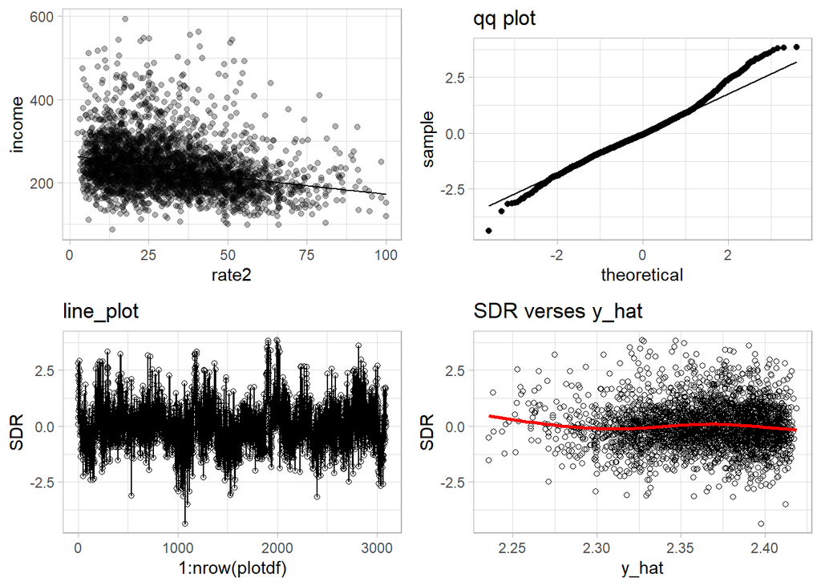

```r
#1990

mod1990<-my_model(test1990_)[[1]]
testplot1990<-mutatedata(test1990_,mod1990)
g90<-drawgrid(testplot1990,'rate2','income')
grid.arrange(g90[[7]],g90[[2]],g90[[4]],g90[[5]],ncol=2)
```

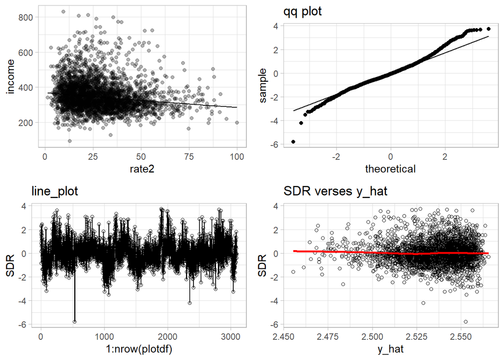

```r
#2000

mod2000<-my_model(test2000_)[[1]]
testplot2000<-mutatedata(test2000_,mod2000)
g00<-drawgrid(testplot2000,'rate2','income')
grid.arrange(g00[[7]],g00[[2]],g00[[4]],g00[[5]],ncol=2)
```

Then we look at the education vs rate of religious population

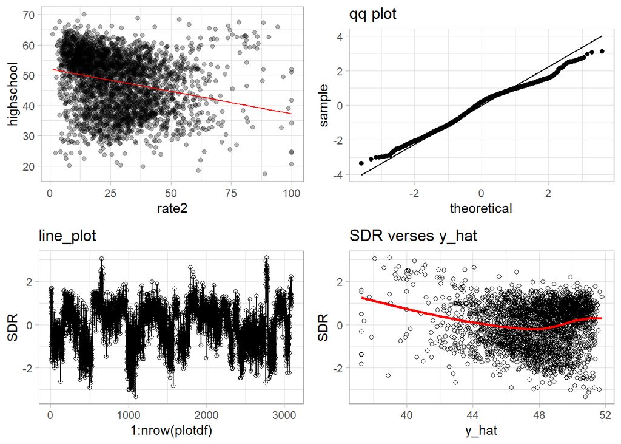

```r
#1980

testplot1980e<-mutatedata(test1980_,my_model(test1980_)[[2]])
gg80<-drawgrid(testplot1980e,'rate2','highschool')
grid.arrange(gg80[[1]],gg80[[2]],gg80[[4]],gg80[[5]],ncol=2)
```

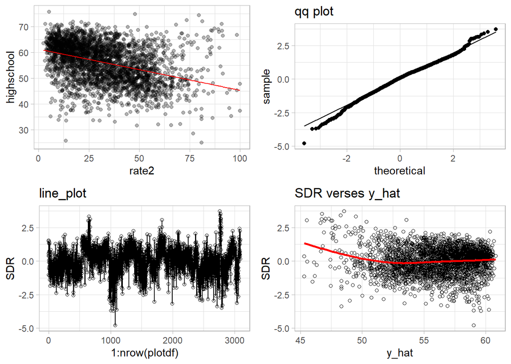

```r
#1990

testplot1990e<-mutatedata(test1990_,my_model(test1990_)[[2]])
gg90<-drawgrid(testplot1990e,'rate2','highschool')
grid.arrange(gg90[[1]],gg90[[2]],gg90[[4]],gg90[[5]],ncol=2)
```

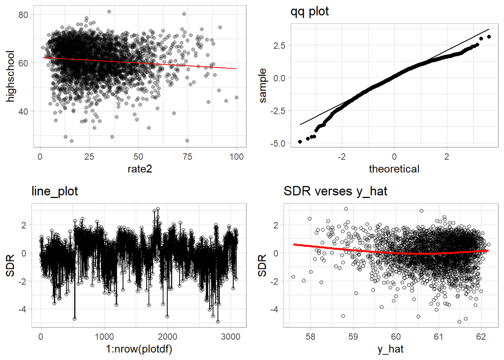

```r
#2000


testplot2000e<-mutatedata(test2000_,my_model(test2000_)[[2]])
gg00<-drawgrid(testplot2000e,'rate2','highschool')
grid.arrange(gg00[[1]],gg00[[2]],gg00[[4]],gg00[[5]],ncol=2)
```

[figure not shown]

```r
#2010


testplot2010e<-mutatedata(test2000_,my_model(test2010_)[[2]])
gg10<-drawgrid(testplot2000e,'rate2','highschool')
grid.arrange(gg10[[1]],gg10[[2]],gg10[[4]],gg10[[5]],ncol=2)
```

We find by the qqplot, the distribution is more closer and less skewed than income distribution.

```r
summary(mod1980)
summary(mod1990)
summary(mod2000)
summary(mod2010)
```

[output not shown]

```r
summary(my_model(test1980_)[[2]])
summary(my_model(test1990_)[[2]])
summary(my_model(test2000_)[[2]])
summary(my_model(test2010_)[[2]])
```

[output not shown]

```r
modelfull1<-lm(income~highschool+rate2+workingrate,data=test1980_)
modelfull2<-lm(income~highschool*rate2+workingrate,data=test1980_)
modelfull3<-lm(income~highschool+rate2*workingrate,data=test1980_)
modelfull4<-lm(income~highschool*workingrate+rate2,data=test1980_)
summary(modelfull1)
```

```
##
## Call:
## lm(formula = income ~ highschool + rate2 + workingrate, data = test1980_)
##
## Residuals:
##      Min       1Q   Median       3Q      Max
## -125.829  -13.676   -1.874   12.545  150.935
##
## Coefficients:
##              Estimate Std. Error t value Pr(>|t|)
## (Intercept) -83.44447    4.69048 -17.790  < 2e-16 ***
## highschool    1.76005    0.04695  37.484  < 2e-16 ***
## rate2         0.12448    0.02893   4.303 1.74e-05 ***
## workingrate 291.00606    8.12075  35.835  < 2e-16 ***
## ---
## Signif. codes:  0 '***' 0.001 '**' 0.01 '*' 0.05 '.' 0.1 ' ' 1
##
## Residual standard error: 23.91 on 3088 degrees of freedom
## Multiple R-squared:  0.5011, Adjusted R-squared:  0.5006
## F-statistic:  1034 on 3 and 3088 DF,  p-value: < 2.2e-16
```

```r
summary(modelfull2)
```

```
##
## Call:
## lm(formula = income ~ highschool * rate2 + workingrate, data = test1980_)
##
## Residuals:
##      Min       1Q   Median       3Q      Max
## -126.223  -13.749   -1.924   12.572  150.807
##
## Coefficients:
##                    Estimate Std. Error t value Pr(>|t|)
## (Intercept)      -81.057772   5.825836 -13.913   <2e-16 ***
## highschool         1.710745   0.085433  20.024   <2e-16 ***
## rate2              0.041478   0.123589   0.336    0.737
## workingrate      291.114637   8.122957  35.839   <2e-16 ***
## highschool:rate2   0.001723   0.002494   0.691    0.490
## ---
## Signif. codes:  0 '***' 0.001 '**' 0.01 '*' 0.05 '.' 0.1 ' ' 1
##
## Residual standard error: 23.91 on 3087 degrees of freedom
## Multiple R-squared:  0.5012, Adjusted R-squared:  0.5005
## F-statistic: 775.3 on 4 and 3087 DF,  p-value: < 2.2e-16
```

```r
summary(modelfull3)
```

```
##
## Call:
## lm(formula = income ~ highschool + rate2 * workingrate, data = test1980_)
##
## Residuals:
##      Min       1Q   Median       3Q      Max
## -112.945  -13.758   -1.801   12.544  192.461
##
## Coefficients:
##                    Estimate Std. Error t value Pr(>|t|)
## (Intercept)       -63.86064    6.81918  -9.365  < 2e-16 ***
## highschool          1.76848    0.04689  37.714  < 2e-16 ***
## rate2              -0.73245    0.21896  -3.345 0.000832 ***
## workingrate       248.36343   13.50150  18.395  < 2e-16 ***
## rate2:workingrate   1.85711    0.47037   3.948 8.05e-05 ***
## ---
## Signif. codes:  0 '***' 0.001 '**' 0.01 '*' 0.05 '.' 0.1 ' ' 1
##
## Residual standard error: 23.85 on 3087 degrees of freedom
## Multiple R-squared:  0.5036, Adjusted R-squared:  0.5029
## F-statistic: 782.9 on 4 and 3087 DF,  p-value: < 2.2e-16
```

```r
summary(modelfull4)
```

```
##
## Call:
## lm(formula = income ~ highschool * workingrate + rate2, data = test1980_)
##
## Residuals:
##      Min       1Q   Median       3Q      Max
## -120.799  -13.794   -1.841   12.450  160.431
##
## Coefficients:
##                         Estimate Std. Error t value Pr(>|t|)
## (Intercept)             66.10077   20.25161   3.264  0.00111 **
## highschool              -1.35374    0.41305  -3.277  0.00106 **
## workingrate            -28.69003   42.89947  -0.669  0.50369
## rate2                    0.13319    0.02869   4.642 3.59e-06 ***
## highschool:workingrate   6.62706    0.87349   7.587 4.31e-14 ***
## ---
## Signif. codes:  0 '***' 0.001 '**' 0.01 '*' 0.05 '.' 0.1 ' ' 1
##
## Residual standard error: 23.69 on 3087 degrees of freedom
## Multiple R-squared:  0.5102, Adjusted R-squared:  0.5096
## F-statistic: 803.9 on 4 and 3087 DF,  p-value: < 2.2e-16
```